# Functions Lab

##### Assignment Instructions

Complete all questions below. After completing the assignment, knit your document, and download both your .Rmd and knitted output. Upload your files for peer review.

For each response, include comments detailing your response and what each line does. Ensure you test your functions with sufficient test cases to identify and correct any potential bugs.

##### Question 1.

Review the roll functions from Section 2 in *Hands-On Programming in R*. Using these functions as an example, create a function that produces a histogram of 50,000 rolls of three 8 sided dice. Each die is loaded so that the number 7 has a higher probability of being rolled than the other numbers, assume all other sides of the die have a 1/10 probability of being rolled.

Your function should contain the arguments `max_rolls`, `sides`, and `num_of_dice`. You may wish to set some of the arguments to default values.

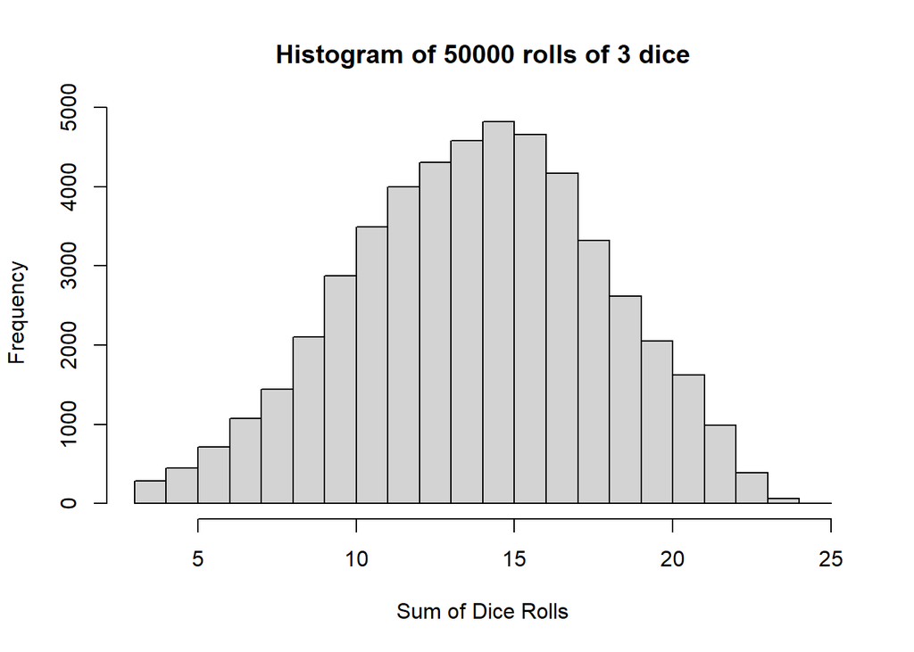

```r
# Function to simulate loaded dice rolls and produce histogram
simulate_loaded_dice_rolls <- function(max_rolls = 50000, sides = 8, num_of_dice = 3) {

  # Define probabilities for each side of the die
  probabilities <- rep(1/10, sides)
  probabilities[7] <- 2/10  # Setting higher probability for number 7

  # Function to roll a single loaded die
  roll_loaded_die <- function() {
    sample(1:sides, size = 1, prob = probabilities)
  }

  # Function to roll multiple dice and sum their outcomes
  roll_loaded_dice <- function(num_dice) {
    sum(replicate(num_dice, roll_loaded_die()))
  }

  # Simulate rolls
  rolls <- replicate(max_rolls, roll_loaded_dice(num_of_dice))

  # Plot histogram
  hist(rolls, breaks = seq(min(rolls), max(rolls) + 1, by = 1),
       main = paste("Histogram of", max_rolls, "rolls of", num_of_dice, "dice"),
       xlab = "Sum of Dice Rolls",
       ylab = "Frequency")
}

# Example usage:
simulate_loaded_dice_rolls()
```